# A8

Dipesh Koirala

12/31/2021

# 1. Check the data with head(mtcars) and save a new data as mtcars.subset after dropping two non-numeric(binary) variables for PCA analysis.

```r
mtcars1 <- mtcars
head(mtcars)
```

```
##                    mpg cyl disp  hp drat    wt  qsec vs am gear carb
## Mazda RX4         21.0   6  160 110 3.90 2.620 16.46  0  1    4    4
## Mazda RX4 Wag     21.0   6  160 110 3.90 2.875 17.02  0  1    4    4
## Datsun 710        22.8   4  108  93 3.85 2.320 18.61  1  1    4    1
## Hornet 4 Drive    21.4   6  258 110 3.08 3.215 19.44  1  0    3    1
## Hornet Sportabout 18.7   8  360 175 3.15 3.440 17.02  0  0    3    2
## Valiant           18.1   6  225 105 2.76 3.460 20.22  1  0    3    1
```

```r
mtcars.subset <- scale(subset(mtcars,select = -c(vs,am)))
head(mtcars.subset)
```

```
##                          mpg        cyl        disp         hp       drat
## Mazda RX4          0.1508848 -0.1049878 -0.57061982 -0.5350928  0.5675137
## Mazda RX4 Wag      0.1508848 -0.1049878 -0.57061982 -0.5350928  0.5675137
## Datsun 710         0.4495434 -1.2248578 -0.99018209 -0.7830405  0.4739996
## Hornet 4 Drive     0.2172534 -0.1049878  0.22009369 -0.5350928 -0.9661175
## Hornet Sportabout -0.2307345  1.0148821  1.04308123  0.4129422 -0.8351978
## Valiant           -0.3302874 -0.1049878 -0.04616698 -0.6080186 -1.5646078
##                             wt       qsec       gear       carb
## Mazda RX4         -0.610399567 -0.7771651  0.4235542  0.7352031
## Mazda RX4 Wag     -0.349785269 -0.4637808  0.4235542  0.7352031
## Datsun 710        -0.917004624  0.4260068  0.4235542 -1.1221521
## Hornet 4 Drive    -0.002299538  0.8904872 -0.9318192 -1.1221521
## Hornet Sportabout  0.227654255 -0.4637808 -0.9318192 -0.5030337
## Valiant            0.248094592  1.3269868 -0.9318192 -1.1221521
```

# 2.Fit the PCA in the as mtcars.pca with mtcars.subset data with cor = TRUE and scores = TRUE.

```r
library(psych,warn.conflicts = F)
mtcars.pca <- principal(mtcars.subset, nfactors = 9, rotate = "none",scores = T,cor = T)
```

#3. Get summary of mtcars.pca and interpret standard deviation and proportion of variance carefully.

```r
mtcars.pca
```

```
## Principal Components Analysis
## Call: principal(r = mtcars.subset, nfactors = 9, rotate = "none", scores = T,
##     cor = T)
## Standardized loadings (pattern matrix) based upon correlation matrix
##        PC1   PC2   PC3   PC4   PC5   PC6   PC7   PC8   PC9 h2      u2 com
## mpg  -0.93  0.04 -0.16  0.00  0.14  0.25  0.12 -0.03  0.02  1 2.2e-16 1.3
## cyl   0.96  0.02 -0.18  0.02 -0.05  0.08  0.05  0.20  0.02  1 2.3e-15 1.2
## disp  0.94 -0.13 -0.06  0.17  0.21 -0.01  0.06 -0.02 -0.10  1 8.9e-16 1.2
## hp    0.87  0.39 -0.01  0.04  0.13  0.12 -0.23 -0.04  0.04  1 1.6e-15 1.6
## drat -0.74  0.49  0.11  0.44 -0.07 -0.01 -0.02  0.03  0.01  1 1.4e-15 2.5
## wt    0.89 -0.25  0.32  0.10  0.08 -0.03  0.14 -0.05  0.08  1 8.9e-16 1.6
## qsec -0.53 -0.70  0.45 -0.02  0.06  0.09 -0.09  0.09 -0.03  1 1.0e-15 2.8
## gear -0.50  0.79  0.15 -0.15  0.24 -0.11  0.03  0.08  0.01  1 1.7e-15 2.2
## carb  0.58  0.70  0.33 -0.11 -0.17  0.13  0.07 -0.03 -0.05  1 1.8e-15 2.7
##
##                        PC1  PC2  PC3  PC4  PC5  PC6  PC7  PC8  PC9
## SS loadings           5.66 2.08 0.50 0.27 0.18 0.12 0.11 0.06 0.02
## Proportion Var        0.63 0.23 0.06 0.03 0.02 0.01 0.01 0.01 0.00
## Cumulative Var        0.63 0.86 0.92 0.95 0.97 0.98 0.99 1.00 1.00
## Proportion Explained  0.63 0.23 0.06 0.03 0.02 0.01 0.01 0.01 0.00
## Cumulative Proportion 0.63 0.86 0.92 0.95 0.97 0.98 0.99 1.00 1.00
##
## Mean item complexity =  1.9
## Test of the hypothesis that 9 components are sufficient.
##
## The root mean square of the residuals (RMSR) is  0
##  with the empirical chi square  0  with prob <  NA
##
## Fit based upon off diagonal values = 1
```

Interpretation: Principal Component Analysis (PCA) is a type of dimensionality reduction algorithm which is used to compress datasets through feature extraction. PCA is used when our data has high number of variables and analyzing all the variables are too tedious. So, instead of analyzing all the variables, the variables are compressed and limited number of variables are created that contains maximum variance of the original data. In the mtcars data, two binary variables are excluded, and 9 principal components are seen using principal method in psych package. The proportion of variance explains that, the first component PC1 explains 63% variance of original data, the second component PC2 explains 23% variance and so on. The standard deviation explains the eigen value of the original data.

#4.Get eigenvalue of the components using standard deviation of mtcars.pca and chose the number of components based on Kaiser’s criteria.

```r
eigen <- mtcars.pca$values
eigen
```

```
## [1] 5.65593947 2.08210029 0.50421482 0.26502753 0.18315864 0.12379319 0.10506192
## [8] 0.05851375 0.02219038
```

According to Kaiser’s criteria, the component having eigen values greater or equal to 1 should be retained. So, observing above eigen values two components PC1 and PC2 can be choosen.

#5.Get scree plot and chose the number of components based on “first bend” of this plot.

```r
var_exp = mtcars.pca$values/sum(mtcars.pca$values)
var_exp
```

```
## [1] 0.628437719 0.231344477 0.056023869 0.029447503 0.020350960 0.013754799
## [7] 0.011673547 0.006501528 0.002465598
```

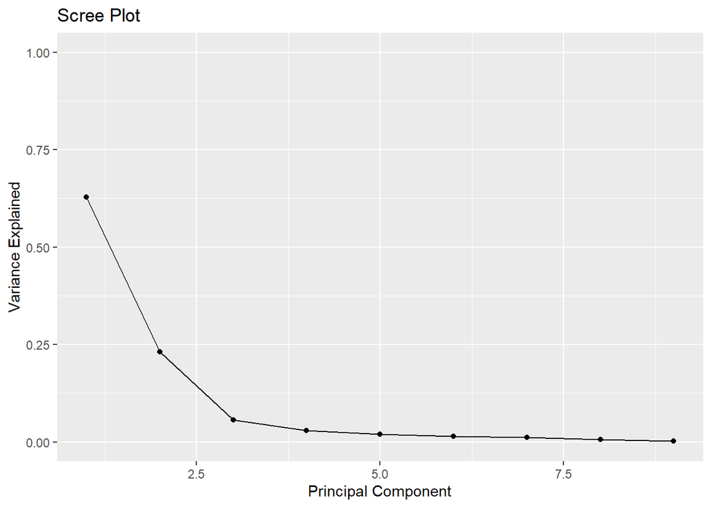

```r
library(ggplot2,warn.conflicts = F)

qplot(c(1:9),var_exp)+
  geom_line()+
  xlab("Principal Component")+
  ylab("Variance Explained")+
  ggtitle("Scree Plot")+
  ylim(0,1)
```

#7.Fit the final PCA model based on the retained components and interpret the values carefully.

```r
mtcars.pca1 <- principal(mtcars.subset,nfactors = 2,rotate="none",scores = T,cor = T)
mtcars.pca1
```

```
## Principal Components Analysis
## Call: principal(r = mtcars.subset, nfactors = 2, rotate = "none", scores = T,
##     cor = T)
## Standardized loadings (pattern matrix) based upon correlation matrix
##        PC1   PC2   h2    u2 com
## mpg  -0.93  0.04 0.88 0.124 1.0
## cyl   0.96  0.02 0.92 0.083 1.0
## disp  0.94 -0.13 0.91 0.091 1.0
## hp    0.87  0.39 0.91 0.087 1.4
## drat -0.74  0.49 0.79 0.207 1.7
## wt    0.89 -0.25 0.85 0.150 1.2
## qsec -0.53 -0.70 0.77 0.227 1.9
## gear -0.50  0.79 0.88 0.120 1.7
## carb  0.58  0.70 0.83 0.173 1.9
##
##                        PC1  PC2
## SS loadings           5.66 2.08
## Proportion Var        0.63 0.23
## Cumulative Var        0.63 0.86
## Proportion Explained  0.73 0.27
## Cumulative Proportion 0.73 1.00
##
## Mean item complexity =  1.4
## Test of the hypothesis that 2 components are sufficient.
##
## The root mean square of the residuals (RMSR) is  0.05
##  with the empirical chi square  6.04  with prob <  1
##
## Fit based upon off diagonal values = 0.99
```

#8.Get the head of the saved loadings of mtcars.pca and interpret the values carefully.

```r
head(mtcars.pca$loadings)
```

```
##             PC1         PC2         PC3         PC4         PC5          PC6
## mpg  -0.9349924  0.03973679 -0.15706498 -0.00315391  0.13727663  0.253381487
## cyl   0.9573620  0.02266837 -0.17916487  0.02095282 -0.05013231  0.078927259
## disp  0.9449932 -0.12825603 -0.05556481  0.17477417  0.20832951 -0.006922559
## hp    0.8730011  0.38875010 -0.01222162  0.03516191  0.12613645  0.124531951
## drat -0.7415688  0.49298721  0.10648022  0.43535196 -0.06929950 -0.005407096
## wt    0.8882114 -0.24810498  0.32218796  0.09846224  0.08023684 -0.029474687
##             PC7         PC8          PC9
## mpg   0.1236179 -0.03015474  0.017120269
## cyl   0.0515152  0.19601372  0.024230983
## disp  0.0590994 -0.01552177 -0.098600723
## hp   -0.2256635 -0.04009185  0.037505214
## drat -0.0154545  0.03266824  0.005674196
## wt    0.1386562 -0.04799069  0.084788796
```

Interpretation: According to above data, the loadings of 9 component of all variables are shown above. These values are the coordinates of the variables divided by the square root of the respective eigen value.

# 9.Retain two components, get their loadings and interpret them carefully.

```r
mtcars.pca1$loadings
```

```
##
## Loadings:
##      PC1    PC2
## mpg  -0.935
## cyl   0.957
## disp  0.945 -0.128
## hp    0.873  0.389
## drat -0.742  0.493
## wt    0.888 -0.248
## qsec -0.534 -0.698
## gear -0.498  0.795
## carb  0.582  0.699
##
##                  PC1   PC2
## SS loadings    5.656 2.082
## Proportion Var 0.628 0.231
## Cumulative Var 0.628 0.860
```

# 10.Get biplot of these two component loadings and interpret them carefully.

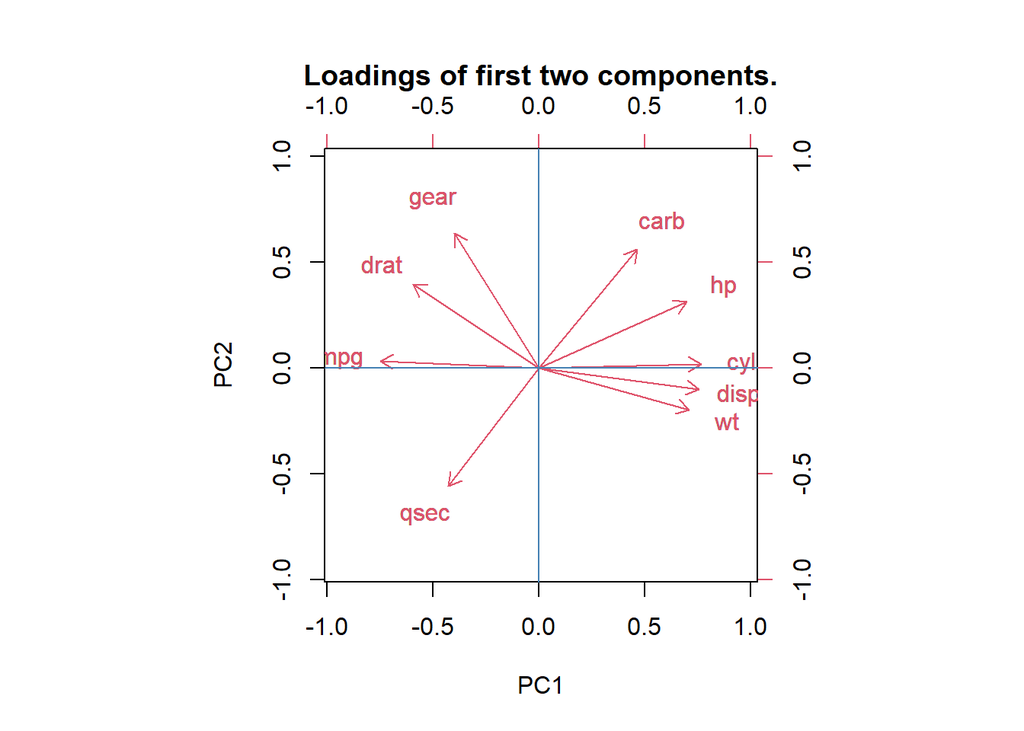

```r
biplot(mtcars.pca1$loadings,mtcars.pca1$loadings ,main = "Loadings of first two components.")
abline(v=0,h=0,col = "steelblue")
```

Interpretation: The above figure shows that, the carb and hp has the loadings of both component positive and qsec has both negative.

#11.Get the head of the saved scores of first two components of mtcars.pca and interpret it carefully.

```r
head(mtcars.pca1$scores)
```

```
##                           PC1        PC2
## Mazda RX4         -0.27929417  0.8132290
## Mazda RX4 Wag     -0.26793045  0.6770476
## Datsun 710        -0.96699807 -0.2263347
## Hornet 4 Drive    -0.09052843 -1.3699797
## Hornet Sportabout  0.66729435 -0.5743299
## Valiant            0.02085807 -1.6956141
```

#12.Get the head of the scores of first two components of mtcars.pca and interpret it carefully.

```r
head(mtcars.pca1$scores)
```

```
##                           PC1        PC2
## Mazda RX4         -0.27929417  0.8132290
## Mazda RX4 Wag     -0.26793045  0.6770476
## Datsun 710        -0.96699807 -0.2263347
## Hornet 4 Drive    -0.09052843 -1.3699797
## Hornet Sportabout  0.66729435 -0.5743299
## Valiant            0.02085807 -1.6956141
```

Interpretation: The above data shows the scores of the first two components of the data.

#13.Get biplot of these two component scores and interpret it carefully.

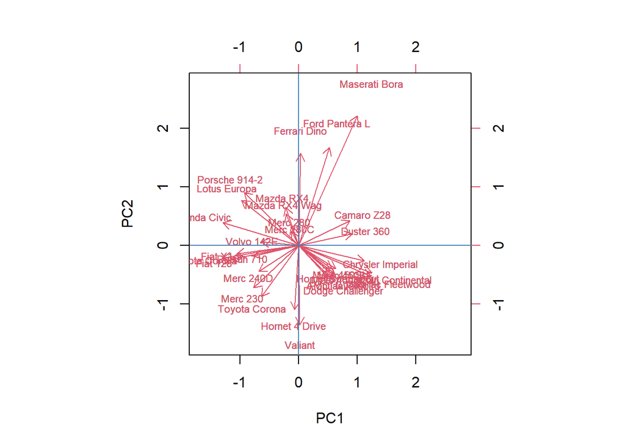

```r
biplot(mtcars.pca1$scores,mtcars.pca1$scores,cex = 0.7)
abline(v=0,h=0,col = "steelblue")
```

Interpretation: The above figure shows the biplot of scores of the two principal components. The scores are high for PC1 positive and PC2 negative and low for both positive.

#14.Get dissimilar distance of all the variables of mtcars data as mtcars.dist.

```r
mtcars.dist <- dist(mtcars)
print(head(mtcars.dist))
```

```
## [1]   0.6153251  54.9086059  98.1125212 210.3374396  65.4717710 241.4076490
```

#15.Fit classical multi-dimensional scaling model with the mtcars.dist in 2-dimensional state as cars.mds.2d

```r
cars.mds.2d <- cmdscale(mtcars.dist)
summary(cars.mds.2d)
```

```
##        V1                V2
##  Min.   :-181.07   Min.   :-139.05
##  1st Qu.:-116.69   1st Qu.: -10.37
##  Median : -43.99   Median :   2.14
##  Mean   :   0.00   Mean   :   0.00
##  3rd Qu.: 132.86   3rd Qu.:  29.37
##  Max.   : 242.81   Max.   :  52.50
```

#16.Plot the cars.mds.2d and compare it with the biplot of mtcars.pca and interpret it carefully.

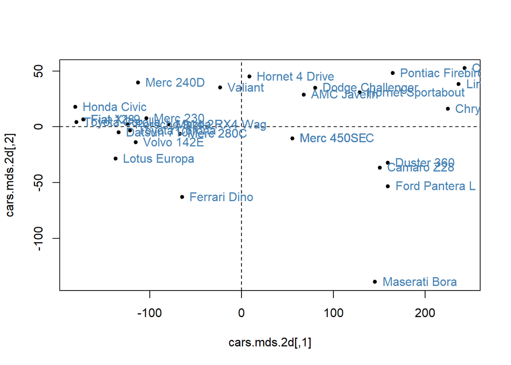

```r
library(dplyr,warn.conflicts = F)
plot(cars.mds.2d,pch=20)
abline(h=0,v=0,lty=2)
mtcars <- mtcars %>% scale()
text(cars.mds.2d,pos = 4,labels = rownames(mtcars),col = "steelblue")
```

Interpretation: The above figure shows the plot of multidimensional scaling model of the data in 2 - dimensional state. Multi-dimensional scaling is also the method of dimensionality reduction as like principal component analysis. Multi dimensional scaling compute the classical distance between points. This method visualize the similarity/disimilarity of the data by plotting points.

#17.Fit classical multi-dimensional scaling model with the mtcars.dist in 3-dimensional state as cars.mds.3d

```r
cars.mds.3d <- cmdscale(mtcars.dist, k=3)
```

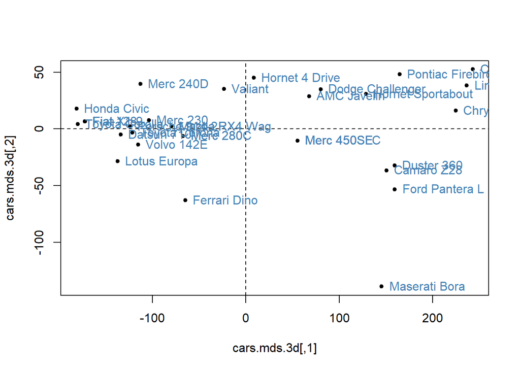

```r
plot(cars.mds.3d,pch=20)
abline(h=0,v=0,lty=2)
mtcars <- mtcars %>% scale()
text(cars.mds.3d,pos = 4,labels = rownames(mtcars),col = "steelblue")
```

# 18.Create a 3-d scatterplot of cars.mds.3d with type = “h”, pch = 20 and lty.hplot = 2 and interpret it carefully.

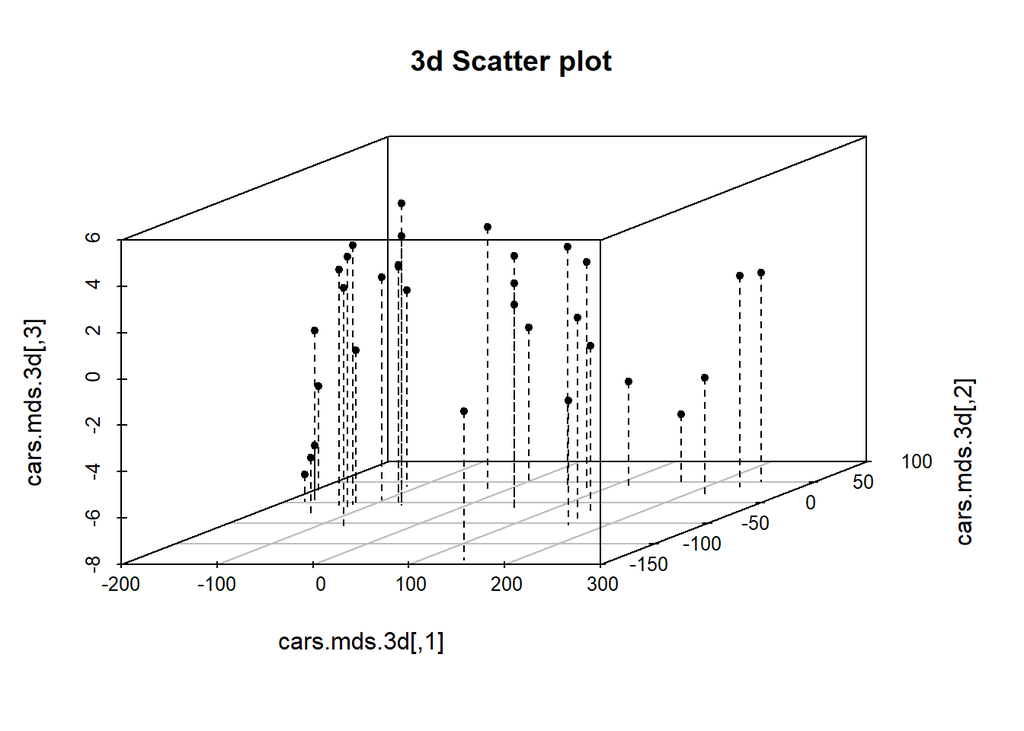

```r
library(scatterplot3d)
scatterplot3d(cars.mds.3d, main = "3d Scatter plot",
              type = "h", pch = 20,
              lty.hplot = 2)
```

Interpretation: The above figure shows the 3d scatter plot of the classical multi-dimensional scaling of mtcars.dist. We can see the distance between the points in 3d. It shows the inter point distance and also the distance from the base.

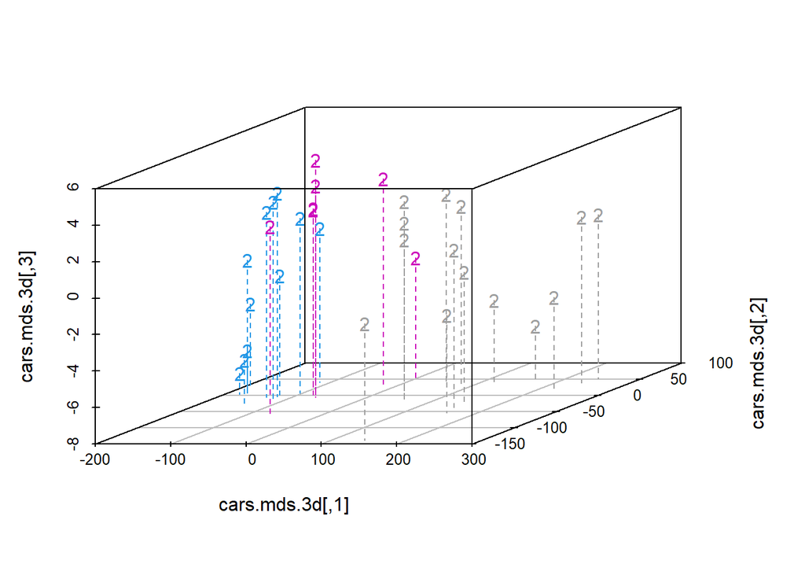

```r
scatterplot3d(cars.mds.3d,type = "h",pch = "20",lty.hplot = 2,color = mtcars1$cyl)
```

Interpretation: The above figure shows the 3d scatter plot of multi-dimensional scaling of mtcars.dist variable.Here we can see the points according to color of mtcars$cyl.

#20.Write a summary comparing PCA and MDS fits done above for mtcars data. PCA is the dimension reduction method, a very useful method when the study domain has many number of variables. This method is to create datasets from the original data less than the number of original data and yet explain most of the variance. In the above data, mtcars data is used, the two binary variables are eliminated from our analysis and for the remaining 9 variables, suitable number of principal components are chosen that explains most of the variance of the 9 variables. Using scre plot and Kaiser’s criteria, two pricipal components are retained that explains about 86% variance of previous 9 components.

Multidimensional scaling is the method to visualize the similarity or dissimilarity between data using plots. This method used distance and in above code, multidimensional scaling id fitted for 2 state dimension and 3 state dimension.